Recently Liess & Beketov, (2011) proposed a new method to analyze mesocosm data: **SPEARmesocosm**.

They classified species into 'SPEciesAtRisk' and 'SPEcies not At Risk' based on three biological traits:

- toxicological sensitivity to organic toxicants
- generation time
- the presence of aquatic stages during contamination

With this classification a SPEAR-value for each sample can be calculated as the relative abundance of sensitive species.  
Their tool to calculate SPEAR is freely available as web-application at http://www.systemecology.eu/SPEAR.

Here I will show how we can use this tool to analyze a mesocosm experiment:

As in the last post we first load the data and packages:

```r
require(vegan)  # for the data
require(xlsx)  # writing to .xls
require(gdata)  # read.xls (don't know why read.xlsx doesn't work)
require(RCurl)  # to read .csv from github
require(reshape2)  # tranform data formats (long / wide)
require(plyr)  # aggregate and transform data
require(ggplot2)  # graphics


# pyrifos data
data(pyrifos)

# The data has been log-transformed, we want to use the raw abundances:
pyrifos <- round((exp(pyrifos) - 1)/10)

# create treatment, time and ditch factors
pyrifos$week <- gl(11, 12, labels = c(-4, -1, 0.1, 1, 2, 4, 8, 12, 15, 19, 24))
pyrifos$dose <- factor(rep(c(0.1, 0, 0, 0.9, 0, 44, 6, 0.1, 44, 0.9, 0, 6),
    11))
pyrifos$ditch <- gl(12, 1, length = 132)
```

The SPEAR-calculator accepts only data in the long format, we can use melt() from the reshape 2 package to bring data from the wide into the long format:

```r
# bring data to long format
pyrifos_melt <- melt(pyrifos, id = c("dose", "week", "ditch"))
```

SPEARmesocosm classifies species based on biological traits. Therefore we need complete taxa names. For ordinations like PRC it doesn´t matter how we name our species, but here the SPEAR algorithm matches the species names with a database.

Unfortunately the data available in vegan contains only abbreviated taxa names.  
I tried to recover the names from the abbreviations, but was not successful for all of the species.  
I made up a table (see my [github repository](https://github.com/EDiLD/r-ed) for this blog) to replace the abbreviations with real taxa names:

```r
# get lookup table for taxa-names from my github repository
csv <- getURL("https://raw.github.com/EDiLD/r-ed/master/post4_prcSPEAR/taxa_names.csv")
taxa_names <- read.table(textConnection(csv), header = TRUE, sep = ";")

# replace taxa names
pyrifos_melt$variable <- taxa_names$taxa[match(pyrifos_melt$variable, taxa_names$abbrv)]

# remove unmatched names
pyrifos_melt <- pyrifos_melt[!is.na(pyrifos_melt$variable), ]
```

Now the data is ready and we have to export it as Excel-file to use it with the SPEAR calculator.

```r
# write to xls
write.xlsx2(pyrifos_melt, file = "spear_in.xlsx", row.names = FALSE)
```

We start the [SPEAR-calculator](http://www.systemecology.eu/SPEAR), start a 'new Mesocosm Study' and import our data which is in stored spear_in.xlsx.

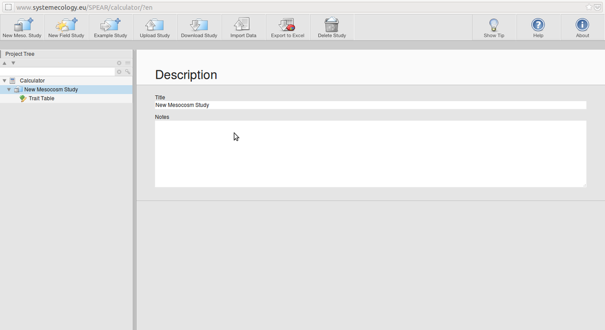

Then we must select the columns coding taxa, abundance, treatment, timing and replicates:

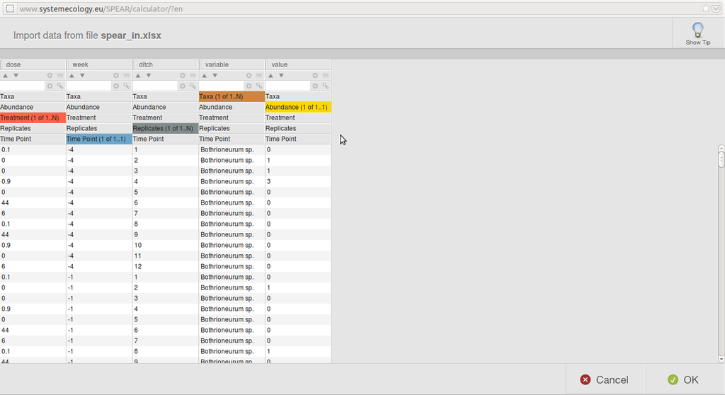

And that´s it: You can browse through the results in the calculator, but also export them to a excel-sheet.  
Since we want to make some nice plots (and perhaps some statistical tests) we export the results to our working directory and name the file 'spear_out.xls'.

```r
# read .xls from SPEAR-calculator
spear <- read.xls("spear_out.xls", sheet = 3)
spear$Treatment <- factor(spear$Treatment)
```

Having the data in R we can make some plots with ggplot2:

- SPEAR against time for all replicates:

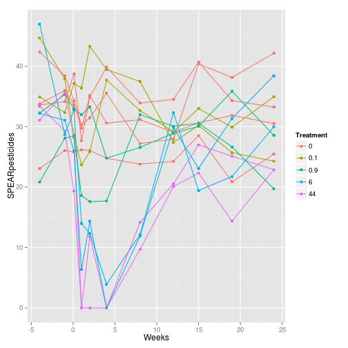

```r
# plot raw
p <- ggplot(spear, aes(x = Time.Point, y = SPEARpesticides, col = Treatment)) +
    geom_point() + geom_line(aes(group = Replicates)) + xlab("Weeks")
p
```

- Hmm, so many lines… We can plot also only the mean Spear values per treatment and time

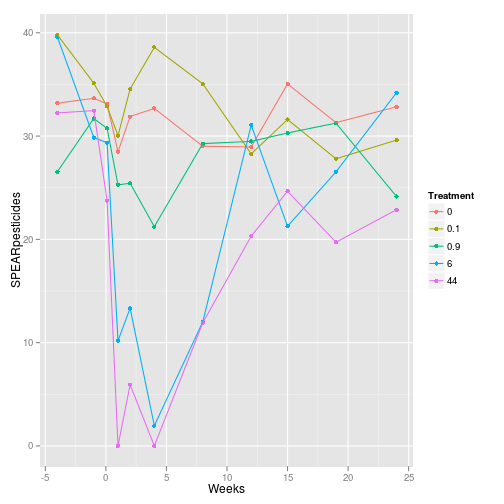

```r
# plot means
spear_means <- ddply(spear, .(Treatment, Time.Point), summarise, mean_spear = mean(SPEARpesticides))

p2 <- ggplot(spear_means, aes(x = Time.Point, y = mean_spear, col = Treatment)) +
    geom_point() + geom_line() + xlab("Weeks") + ylab("SPEARpesticides")
p2
```

- Or, to get a plot similar to the Principle Response Curves: Plot the difference of treatments to the control

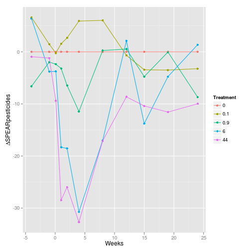

```r
# plot difference to control
spear_relcont <- ddply(spear_means, .(Time.Point), transform, mean_spear = mean_spear -
    mean_spear[Treatment == 0])

p3 <- ggplot(spear_relcont, aes(x = Time.Point, y = mean_spear, col = Treatment)) +
    geom_point() + geom_line() + xlab("Weeks") + ylab(expression(paste(Delta,
    "SPEARpesticides")))
p3
```

We see, that the graphs from SPEARmesocosm and Principle Response Curves look similar,  
although it must be noted that here I used only a subset of species (because i could not recover all species names).

The SPEARmesocosm-values could be further analysed with univariate methods, but I'll skip that for now.

Next time I'll analyze the sama dataset using the mvabund-package.

**Refs**

Liess M and Beketov M (2011).  
“Traits And Stress: Keys to Identify Community Effects of Low Levels of Toxicants in Test Systems.”  
*Ecotoxicology*, **20**.  
ISSN 0963-9292, http://dx.doi.org/10.1007/s10646-011-0689-y.